# pytorch - GPU

Lecture 24

Dr. Colin Rundel

## CUDA

> CUDA (or Compute Unified Device Architecture) is a parallel computing platform and application programming interface (API) that allows software to use certain types of graphics processing unit (GPU) for general purpose processing, an approach called general-purpose computing on GPUs (GPGPU). CUDA is a software layer that gives direct access to the GPU’s virtual instruction set and parallel computational elements, for the execution of compute kernels.

Core libraries:

- cuBLAS
- cuSOLVER
- cuSPARSE
- cuFFT
- cuTENSOR
- cuRAND
- Thrust
- cuDNN

## CUDA Kernels

```c
// Kernel - Adding two matrices MatA and MatB
__global__ void MatAdd(float MatA[N][N], float MatB[N][N], float MatC[N][N])
{
    int i = blockIdx.x * blockDim.x + threadIdx.x;
    int j = blockIdx.y * blockDim.y + threadIdx.y;
    if (i < N && j < N)
        MatC[i][j] = MatA[i][j] + MatB[i][j];
}

int main()
{
    ...
    // Matrix addition kernel launch from host code
    dim3 threadsPerBlock(16, 16);
    dim3 numBlocks(
        (N + threadsPerBlock.x -1) / threadsPerBlock.x,
        (N+threadsPerBlock.y -1) / threadsPerBlock.y
    );

    MatAdd<<<numBlocks, threadsPerBlock>>>(MatA, MatB, MatC);
    ...
}
```

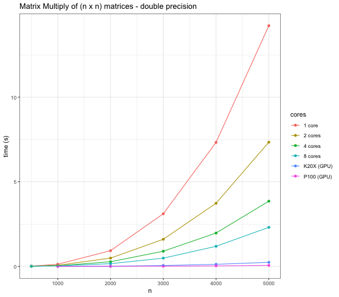

[figure not shown]

## GPU Status

```bash
nvidia-smi
```

```
Sun Apr  9 21:57:13 2023
+---------------------------------------------------------------------------------------+
| NVIDIA-SMI 530.30.02              Driver Version: 530.30.02    CUDA Version: 12.1     |
|-----------------------------------------+----------------------+----------------------+
| GPU  Name                  Persistence-M| Bus-Id        Disp.A | Volatile Uncorr. ECC |
| Fan  Temp  Perf            Pwr:Usage/Cap|         Memory-Usage | GPU-Util  Compute M. |
|                                         |                      |               MIG M. |
|=========================================+======================+======================|
|   0  Tesla P100-PCIE-16GB            Off| 00000000:02:00.0 Off |                    0 |
| N/A   39C    P0               31W / 250W|   1046MiB / 16384MiB |      0%      Default |
|                                         |                      |                  N/A |
+-----------------------------------------+----------------------+----------------------+
|   1  Tesla P100-PCIE-16GB            Off| 00000000:03:00.0 Off |                    0 |
| N/A   39C    P0               27W / 250W|      2MiB / 16384MiB |      0%      Default |
|                                         |                      |                  N/A |
+-----------------------------------------+----------------------+----------------------+

+---------------------------------------------------------------------------------------+
| Processes:                                                                            |
|  GPU   GI   CI        PID   Type   Process name                            GPU Memory |
|        ID   ID                                                             Usage      |
|=======================================================================================|
|    0   N/A  N/A   1622701      C   /usr/lib/rstudio-server/bin/rsession       1044MiB |
+---------------------------------------------------------------------------------------+
```

## Torch GPU Information

```python
torch.cuda.is_available()
```

```
True
```

```python
torch.cuda.device_count()
```

```
2
```

```python
torch.cuda.get_device_name("cuda:0")
```

```
'Tesla P100-PCIE-16GB'
```

```python
torch.cuda.get_device_name("cuda:1")
```

```
'Tesla P100-PCIE-16GB'
```

```python
torch.cuda.get_device_properties(0)
```

```
_CudaDeviceProperties(name='Tesla P100-PCIE-16GB', major=6, minor=0, total_memory=16276MB, multi_processor_count=56)
```

```python
torch.cuda.get_device_properties(1)
```

```
_CudaDeviceProperties(name='Tesla P100-PCIE-16GB', major=6, minor=0, total_memory=16276MB, multi_processor_count=56)
```

## GPU Tensors

Usage of the GPU is governed by the location of the Tensors - to use the GPU we allocate them on the GPU device.

```python
cpu = torch.device('cpu')
cuda0 = torch.device('cuda:0')
cuda1 = torch.device('cuda:1')

x = torch.linspace(0,1,5, device=cuda0); x
```

```
tensor([0.0000, 0.2500, 0.5000, 0.7500, 1.0000], device='cuda:0')
```

```python
y = torch.randn(5,2, device=cuda0); y
```

```
tensor([[-0.0167,  2.1278],
        [ 0.0604,  0.4291],
        [ 1.4372, -1.1069],
        [ 0.6483,  0.0368],
        [ 0.2506, -0.9209]], device='cuda:0')
```

```python
z = torch.rand(2,3, device=cpu); z
```

```
tensor([[0.3012, 0.2347, 0.6459],
        [0.2868, 0.7539, 0.1038]])
```

```python
x @ y
```

```
tensor([ 1.4706, -1.3395], device='cuda:0')
```

```python
y @ z
```

```
Error: RuntimeError: Expected all tensors to be on the same device, but found at least two devices, cuda:0 and cpu! (when checking argument for argument mat2 in method wrapper_CUDA_mm)
```

```python
y @ z.to(cuda0)
```

```
tensor([[ 0.6053,  1.6003,  0.2101],
        [ 0.1413,  0.3377,  0.0836],
        [ 0.1154, -0.4973,  0.8134],
        [ 0.2058,  0.1799,  0.4226],
        [-0.1887, -0.6355,  0.0663]], device='cuda:0')
```

## NN Layers + GPU

NN layers (parameters) also need to be assigned to the GPU to be used with GPU tensors,

```python
nn = torch.nn.Linear(5,5)
X = torch.randn(10,5).cuda()
```

```python
nn(X)
```

```
Error: RuntimeError: Expected all tensors to be on the same device, but found at least two devices, cpu and cuda:0! (when checking argument for argument mat1 in method wrapper_CUDA_addmm)
```

```python
nn.cuda()(X)
```

```
tensor([[-0.4240,  0.8771,  0.9791,  2.2121,  0.0135],
        [ 0.2007, -0.3752, -0.9178, -0.0525,  0.5035],
        [ 0.0040, -0.2651,  0.4492,  0.5128,  0.1479],
        [ 0.8479, -0.8731, -0.7177, -0.5812,  0.8132],
        [ 0.2257, -0.0976, -0.2809,  0.4444,  0.3778],
        [-0.0177, -0.8570, -1.2056, -0.9083,  0.4657],
        [ 0.2076, -0.0661, -0.2684,  0.3879,  0.5412],
        [ 0.6051, -0.1777, -0.6561,  0.9730,  0.6301],
        [ 0.5958, -0.5805, -1.9912, -0.4889,  0.8762],
        [-1.2633, -0.3288, -0.0992,  0.1369, -0.8006]], device='cuda:0',
       grad_fn=<AddmmBackward0>)
```

```python
nn.to(device="cuda")(X)
```

```
tensor([[-0.4240,  0.8771,  0.9791,  2.2121,  0.0135],
        [ 0.2007, -0.3752, -0.9178, -0.0525,  0.5035],
        [ 0.0040, -0.2651,  0.4492,  0.5128,  0.1479],
        [ 0.8479, -0.8731, -0.7177, -0.5812,  0.8132],
        [ 0.2257, -0.0976, -0.2809,  0.4444,  0.3778],
        [-0.0177, -0.8570, -1.2056, -0.9083,  0.4657],
        [ 0.2076, -0.0661, -0.2684,  0.3879,  0.5412],
        [ 0.6051, -0.1777, -0.6561,  0.9730,  0.6301],
        [ 0.5958, -0.5805, -1.9912, -0.4889,  0.8762],
        [-1.2633, -0.3288, -0.0992,  0.1369, -0.8006]], device='cuda:0',
       grad_fn=<AddmmBackward0>)
```

## Back to MNIST

Same MNIST data from last time (1x8x8 images),

```python
from sklearn.datasets import load_digits
from sklearn.model_selection import train_test_split

digits = load_digits()
X, y = digits.data, digits.target

X_train, X_test, y_train, y_test = train_test_split(
    X, y, test_size=0.20, shuffle=True, random_state=1234
)

X_train = torch.from_numpy(X_train).float()
y_train = torch.from_numpy(y_train)
X_test = torch.from_numpy(X_test).float()
y_test = torch.from_numpy(y_test)
```

To use the GPU for computation we need to copy these tensors to the GPU,

```python
X_train_cuda = X_train.to(device=cuda0)
y_train_cuda = y_train.to(device=cuda0)
X_test_cuda = X_test.to(device=cuda0)
y_test_cuda = y_test.to(device=cuda0)
```

## Convolutional NN

```python
class mnist_conv_model(torch.nn.Module):
    def __init__(self, device):
        super().__init__()
        self.device = torch.device(device)

        self.model = torch.nn.Sequential(
          torch.nn.Unflatten(1, (1,8,8)),
          torch.nn.Conv2d(
            in_channels=1, out_channels=8,
            kernel_size=3, stride=1, padding=1
          ),
          torch.nn.ReLU(),
          torch.nn.MaxPool2d(kernel_size=2),
          torch.nn.Flatten(),
          torch.nn.Linear(8 * 4 * 4, 10)
        ).to(device=self.device)

    def forward(self, X):
        return self.model(X)

    def fit(self, X, y, lr=0.001, n=1000, acc_step=10):
      opt = torch.optim.SGD(self.parameters(), lr=lr, momentum=0.9)
      losses = []
      for i in range(n):
          opt.zero_grad()
          loss = torch.nn.CrossEntropyLoss()(self(X), y)
          loss.backward()
          opt.step()
          losses.append(loss.item())

      return losses

    def accuracy(self, X, y):
      val, pred = torch.max(self(X), dim=1)
      return( (pred == y).sum() / len(y) )
```

## CPU vs Cuda

```python
m = mnist_conv_model(device="cpu")
loss = m.fit(X_train, y_train, n=1000)
loss[-1]
```

```
0.025411752983927727
```

```python
m.accuracy(X_test, y_test)
```

```
tensor(0.9778)
```

```python
m_cuda = mnist_conv_model(device="cuda")
loss = m_cuda.fit(X_train_cuda, y_train_cuda, n=1000)
loss[-1]
```

```
0.03171907365322113
```

```python
m_cuda.accuracy(X_test_cuda, y_test_cuda)
```

```
tensor(0.9778, device='cuda:0')
```

## Performance

CPU performance:

```python
m = mnist_conv_model(device="cpu")

start = torch.cuda.Event(enable_timing=True)
end = torch.cuda.Event(enable_timing=True)

start.record()
loss = m.fit(X_train, y_train, n=1000)
end.record()

torch.cuda.synchronize()
print(start.elapsed_time(end) / 1000)
```

```
2.660278564453125
```

GPU performance:

```python
m_cuda = mnist_conv_model(device="cuda")

start = torch.cuda.Event(enable_timing=True)
end = torch.cuda.Event(enable_timing=True)

start.record()
loss = m_cuda.fit(X_train_cuda, y_train_cuda, n=1000)
end.record()

torch.cuda.synchronize()
print(start.elapsed_time(end) / 1000)
```

```
2.37678125
```

## Profiling CPU

```python
m = mnist_conv_model(device="cpu")
with torch.autograd.profiler.profile(with_stack=True, profile_memory=True) as prof_cpu:
    tmp = m(X_train)
```

```python
print(prof_cpu.key_averages().table(sort_by='self_cpu_time_total', row_limit=5))
```

```
---------------------------------  ------------  ------------  ------------  ------------  ------------  ------------  ------------  ------------
                             Name    Self CPU %      Self CPU   CPU total %     CPU total  CPU time avg       CPU Mem  Self CPU Mem    # of Calls
---------------------------------  ------------  ------------  ------------  ------------  ------------  ------------  ------------  ------------
         aten::mkldnn_convolution        50.73%       1.140ms        51.62%       1.160ms       1.160ms       2.81 Mb           0 b             1
    aten::max_pool2d_with_indices        26.52%     596.000us        26.52%     596.000us     596.000us       2.10 Mb       2.10 Mb             1
                  aten::clamp_min        11.97%     269.000us        11.97%     269.000us     269.000us       2.81 Mb       2.81 Mb             1
                      aten::addmm         2.98%      67.000us         4.05%      91.000us      91.000us      56.13 Kb      56.13 Kb             1
                aten::convolution         1.56%      35.000us        53.63%       1.205ms       1.205ms       2.81 Mb           0 b             1
---------------------------------  ------------  ------------  ------------  ------------  ------------  ------------  ------------  ------------
Self CPU time total: 2.247ms
```

## Profiling GPU

```python
m_cuda = mnist_conv_model(device="cuda")
with torch.autograd.profiler.profile(with_stack=True) as prof_cuda:
    tmp = m_cuda(X_train_cuda)
```

```python
print(prof_cuda.key_averages().table(sort_by='self_cpu_time_total', row_limit=5))
```

```
-------------------------------------------------  ------------  ------------  ------------  ------------  ------------  ------------
                                             Name    Self CPU %      Self CPU   CPU total %     CPU total  CPU time avg    # of Calls
-------------------------------------------------  ------------  ------------  ------------  ------------  ------------  ------------
                          aten::cudnn_convolution        83.46%       1.797ms        84.72%       1.824ms       1.824ms             1
                                      aten::addmm         4.27%      92.000us         5.25%     113.000us     113.000us             1
                                 cudaLaunchKernel         2.97%      64.000us         2.97%      64.000us       9.143us             7
                               aten::_convolution         1.81%      39.000us        88.39%       1.903ms       1.903ms             1
                    aten::max_pool2d_with_indices         1.11%      24.000us         1.49%      32.000us      32.000us             1
-------------------------------------------------  ------------  ------------  ------------  ------------  ------------  ------------
Self CPU time total: 2.153ms
```

# CIFAR10

[homepage](https://www.cs.toronto.edu/~kriz/cifar.html)

## Loading the data

```python
import torchvision

training_data = torchvision.datasets.CIFAR10(
    root="/data",
    train=True,
    download=True,
    transform=torchvision.transforms.ToTensor()
)
```

```
Files already downloaded and verified
```

```python
test_data = torchvision.datasets.CIFAR10(
    root="/data",
    train=False,
    download=True,
    transform=torchvision.transforms.ToTensor()
)
```

```
Files already downloaded and verified
```

## CIFAR10 data

```python
training_data.classes
```

```
['airplane', 'automobile', 'bird', 'cat', 'deer', 'dog', 'frog', 'horse', 'ship', 'truck']
```

```python
training_data.data.shape
```

```
(50000, 32, 32, 3)
```

```python
test_data.data.shape
```

```
(10000, 32, 32, 3)
```

```python
training_data[0]
```

```
(tensor([[[0.2314, 0.1686, 0.1961,  ..., 0.6196, 0.5961, 0.5804],
         [0.0627, 0.0000, 0.0706,  ..., 0.4824, 0.4667, 0.4784],
         [0.0980, 0.0627, 0.1922,  ..., 0.4627, 0.4706, 0.4275],
         ...,
         [0.8157, 0.7882, 0.7765,  ..., 0.6275, 0.2196, 0.2078],
         [0.7059, 0.6784, 0.7294,  ..., 0.7216, 0.3804, 0.3255],
         [0.6941, 0.6588, 0.7020,  ..., 0.8471, 0.5922, 0.4824]],

        [[0.2431, 0.1804, 0.1882,  ..., 0.5176, 0.4902, 0.4863],
         [0.0784, 0.0000, 0.0314,  ..., 0.3451, 0.3255, 0.3412],
         [0.0941, 0.0275, 0.1059,  ..., 0.3294, 0.3294, 0.2863],
         ...,
         [0.6667, 0.6000, 0.6314,  ..., 0.5216, 0.1216, 0.1333],
         [0.5451, 0.4824, 0.5647,  ..., 0.5804, 0.2431, 0.2078],
         [0.5647, 0.5059, 0.5569,  ..., 0.7216, 0.4627, 0.3608]],

        [[0.2471, 0.1765, 0.1686,  ..., 0.4235, 0.4000, 0.4039],
         [0.0784, 0.0000, 0.0000,  ..., 0.2157, 0.1961, 0.2235],
         [0.0824, 0.0000, 0.0314,  ..., 0.1961, 0.1961, 0.1647],
         ...,
         [0.3765, 0.1333, 0.1020,  ..., 0.2745, 0.0275, 0.0784],
         [0.3765, 0.1647, 0.1176,  ..., 0.3686, 0.1333, 0.1333],
         [0.4549, 0.3686, 0.3412,  ..., 0.5490, 0.3294, 0.2824]]]), 6)
```

## Example data

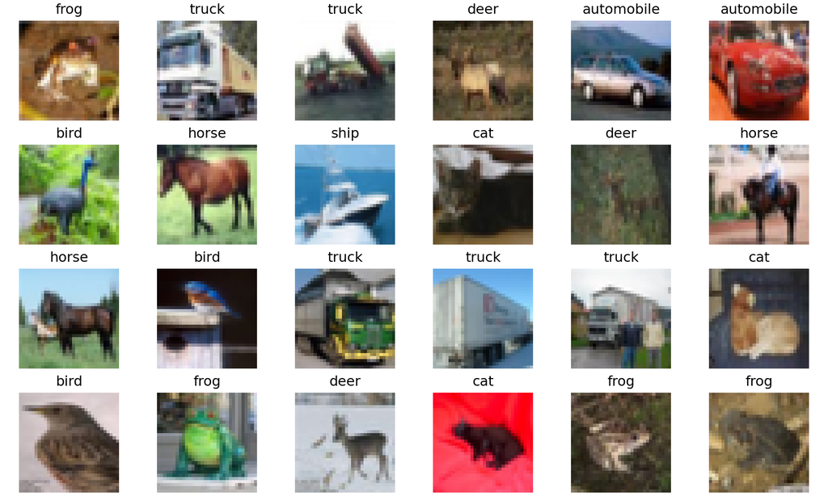

## Data Loaders

```python
batch_size = 100

training_loader = torch.utils.data.DataLoader(
    training_data,
    batch_size=batch_size,
    shuffle=True,
    num_workers=4,
    pin_memory=True
)

test_loader = torch.utils.data.DataLoader(
    test_data,
    batch_size=batch_size,
    shuffle=True,
    num_workers=4,
    pin_memory=True
)
```

## Loader generator

```python
training_loader
```

```
<torch.utils.data.dataloader.DataLoader object at 0x7f1a14f20750>
```

```python
X, y = next(iter(training_loader))
X.shape
```

```
torch.Size([100, 3, 32, 32])
```

```python
y.shape
```

```
torch.Size([100])
```

## CIFAR CNN

```python
class cifar_conv_model(torch.nn.Module):
    def __init__(self, device):
        super().__init__()
        self.device = torch.device(device)
        self.epoch = 0
        self.model = torch.nn.Sequential(
            torch.nn.Conv2d(3, 6, kernel_size=5),
            torch.nn.ReLU(),
            torch.nn.MaxPool2d(2, 2),
            torch.nn.Conv2d(6, 16, kernel_size=5),
            torch.nn.ReLU(),
            torch.nn.MaxPool2d(2, 2),
            torch.nn.Flatten(),
            torch.nn.Linear(16 * 5 * 5, 120),
            torch.nn.ReLU(),
            torch.nn.Linear(120, 84),
            torch.nn.ReLU(),
            torch.nn.Linear(84, 10)
        ).to(device=self.device)

    def forward(self, X):
        return self.model(X)

    def fit(self, loader, epochs=10, n_report=250, lr=0.001):
        opt = torch.optim.SGD(self.parameters(), lr=lr, momentum=0.9)

        for j in range(epochs):
            running_loss = 0.0
            for i, (X, y) in enumerate(loader):
                X, y = X.to(self.device), y.to(self.device)
                opt.zero_grad()
                loss = torch.nn.CrossEntropyLoss()(self(X), y)
                loss.backward()
                opt.step()

                # print statistics
                running_loss += loss.item()
                if i % n_report == (n_report-1):    # print every 100 mini-batches
                    print(f'[Epoch {self.epoch + 1}, Minibatch {i + 1:4d}] loss: {running_loss / n_report:.3f}')
                    running_loss = 0.0

            self.epoch += 1
```

Based on [source](https://pytorch.org/tutorials/beginner/blitz/cifar10_tutorial.html)

## CNN Performance - CPU (1 step)

```python
m_cpu = cifar_conv_model(device="cpu")
X, y = next(iter(training_loader))
with torch.autograd.profiler.profile(with_stack=True) as prof_cpu:
    tmp = m_cpu(X)
```

```python
print(prof_cpu.key_averages().table(sort_by='self_cpu_time_total', row_limit=5))
```

```
---------------------------------  ------------  ------------  ------------  ------------  ------------  ------------
                             Name    Self CPU %      Self CPU   CPU total %     CPU total  CPU time avg    # of Calls
---------------------------------  ------------  ------------  ------------  ------------  ------------  ------------
         aten::mkldnn_convolution        62.57%       3.061ms        63.23%       3.093ms       1.546ms             2
    aten::max_pool2d_with_indices        22.65%       1.108ms        22.65%       1.108ms     554.000us             2
                      aten::addmm         5.74%     281.000us         6.91%     338.000us     112.667us             3
                  aten::clamp_min         2.84%     139.000us         2.84%     139.000us      34.750us             4
                       aten::relu         0.98%      48.000us         3.82%     187.000us      46.750us             4
---------------------------------  ------------  ------------  ------------  ------------  ------------  ------------
Self CPU time total: 4.892ms
```

## CNN Performance - GPU (1 step)

```python
m_cuda = cifar_conv_model(device="cuda")
X, y = next(iter(training_loader))
with torch.autograd.profiler.profile(with_stack=True) as prof_cuda:
    X, y = X.to(device="cuda"), y.to(device="cuda")
    tmp = m_cuda(X)
```

```python
print(prof_cuda.key_averages().table(sort_by='self_cpu_time_total', row_limit=5))
```

```
-------------------------------------------------  ------------  ------------  ------------  ------------  ------------  ------------
                                             Name    Self CPU %      Self CPU   CPU total %     CPU total  CPU time avg    # of Calls
-------------------------------------------------  ------------  ------------  ------------  ------------  ------------  ------------
    cudaOccupancyMaxActiveBlocksPerMultiprocessor        29.23%       4.837ms        29.23%       4.837ms     193.480us            25
                          aten::cudnn_convolution        28.63%       4.738ms        82.98%      13.733ms       6.867ms             2
                                 cudaLaunchKernel        25.77%       4.264ms        25.77%       4.264ms     224.421us            19
                                         aten::to         9.50%       1.572ms        11.07%       1.832ms     916.000us             2
                                       cudaMalloc         1.46%     242.000us         1.46%     242.000us     242.000us             1
-------------------------------------------------  ------------  ------------  ------------  ------------  ------------  ------------
Self CPU time total: 16.549ms
```

## CNN Performance - CPU (1 epoch)

```python
m_cpu = cifar_conv_model(device="cpu")
with torch.autograd.profiler.profile(with_stack=True) as prof_cpu:
    m_cpu.fit(loader=training_loader, epochs=1, n_report=501)
```

```python
print(prof_cpu.key_averages().table(sort_by='self_cpu_time_total', row_limit=5))
```

```
-------------------------------------------------------  ------------  ------------  ------------  ------------  ------------  ------------
                                                   Name    Self CPU %      Self CPU   CPU total %     CPU total  CPU time avg    # of Calls
-------------------------------------------------------  ------------  ------------  ------------  ------------  ------------  ------------
                             aten::convolution_backward        28.15%     946.987ms        28.50%     958.800ms     958.800us          1000
                               aten::mkldnn_convolution        17.93%     603.146ms        18.25%     614.086ms     614.086us          1000
                          aten::max_pool2d_with_indices         9.88%     332.527ms         9.89%     332.907ms     332.907us          1000
enumerate(DataLoader)#_MultiProcessingDataLoaderIter...         8.71%     293.065ms         8.76%     294.829ms     588.481us           501
                                Optimizer.step#SGD.step         5.98%     201.362ms         9.25%     311.247ms     622.494us           500
-------------------------------------------------------  ------------  ------------  ------------  ------------  ------------  ------------
Self CPU time total: 3.365s
```

## CNN Performance - GPU (1 epoch)

```python
m_cuda = cifar_conv_model(device="cuda")
with torch.autograd.profiler.profile(with_stack=True) as prof_cuda:
    m_cuda.fit(loader=training_loader, epochs=1, n_report=501)
```

```python
print(prof_cuda.key_averages().table(sort_by='self_cpu_time_total', row_limit=5))
```

```
-------------------------------------------------------  ------------  ------------  ------------  ------------  ------------  ------------
                                                   Name    Self CPU %      Self CPU   CPU total %     CPU total  CPU time avg    # of Calls
-------------------------------------------------------  ------------  ------------  ------------  ------------  ------------  ------------
                                       cudaLaunchKernel        11.69%     323.735ms        11.69%     323.855ms      11.567us         27998
enumerate(DataLoader)#_MultiProcessingDataLoaderIter...        11.53%     319.351ms        11.61%     321.730ms     642.176us           501
                                Optimizer.step#SGD.step         8.76%     242.605ms        11.65%     322.692ms     645.384us           500
                             aten::convolution_backward         5.61%     155.467ms         9.68%     268.279ms     268.279us          1000
                                            aten::addmm         5.07%     140.401ms         6.94%     192.296ms     128.197us          1500
-------------------------------------------------------  ------------  ------------  ------------  ------------  ------------  ------------
Self CPU time total: 2.770s
```

## CNN Performance - CPU (2 epochs)

```python
m_cpu = cifar_conv_model(device="cpu")
with torch.autograd.profiler.profile(with_stack=True) as prof_cpu:
    m_cpu.fit(loader=training_loader, epochs=2, n_report=501)
```

```python
print(prof_cpu.key_averages().table(sort_by='self_cpu_time_total', row_limit=5))
```

```
-------------------------------------------------------  ------------  ------------  ------------  ------------  ------------  ------------
                                                   Name    Self CPU %      Self CPU   CPU total %     CPU total  CPU time avg    # of Calls
-------------------------------------------------------  ------------  ------------  ------------  ------------  ------------  ------------
                             aten::convolution_backward        28.45%        2.144s        28.85%        2.174s       1.087ms          2000
                               aten::mkldnn_convolution        17.47%        1.316s        17.83%        1.343s     671.648us          2000
                          aten::max_pool2d_with_indices         8.00%     603.082ms         8.01%     603.481ms     301.740us          2000
enumerate(DataLoader)#_MultiProcessingDataLoaderIter...         6.89%     519.065ms         6.92%     521.683ms     520.642us          1002
                               aten::threshold_backward         5.61%     423.051ms         5.62%     423.385ms     105.846us          4000
-------------------------------------------------------  ------------  ------------  ------------  ------------  ------------  ------------
Self CPU time total: 7.535s
```

## CNN Performance - GPU (2 epochs)

```python
m_cuda = cifar_conv_model(device="cuda")
with torch.autograd.profiler.profile(with_stack=True) as prof_cuda:
    m_cuda.fit(loader=training_loader, epochs=2, n_report=501)
```

```python
print(prof_cuda.key_averages().table(sort_by='self_cpu_time_total', row_limit=5))
```

```
-------------------------------------------------------  ------------  ------------  ------------  ------------  ------------  ------------
                                                   Name    Self CPU %      Self CPU   CPU total %     CPU total  CPU time avg    # of Calls
-------------------------------------------------------  ------------  ------------  ------------  ------------  ------------  ------------
enumerate(DataLoader)#_MultiProcessingDataLoaderIter...        13.15%     782.271ms        13.23%     787.114ms     785.543us          1002
                                       cudaLaunchKernel        11.41%     679.137ms        11.42%     679.404ms      12.133us         55998
                                Optimizer.step#SGD.step         8.66%     515.551ms        11.72%     697.387ms     697.387us          1000
                                            aten::addmm         5.29%     314.714ms         7.23%     429.920ms     143.307us          3000
                             aten::convolution_backward         5.11%     303.855ms         9.03%     537.183ms     268.591us          2000
-------------------------------------------------------  ------------  ------------  ------------  ------------  ------------  ------------
Self CPU time total: 5.950s
```

## Loaders & Accuracy

```python
def accuracy(model, loader, device):
    total, correct = 0, 0
    with torch.no_grad():
        for X, y in loader:
            X, y = X.to(device=device), y.to(device=device)
            pred = model(X)
            # the class with the highest energy is what we choose as prediction
            val, idx = torch.max(pred, 1)
            total += pred.size(0)
            correct += (idx == y).sum().item()

    return correct / total
```

## Model fitting

```python
m = cifar_conv_model("cuda")
m.fit(training_loader, epochs=10, n_report=500, lr=0.01)

## [Epoch 1, Minibatch  500] loss: 2.098
## [Epoch 2, Minibatch  500] loss: 1.692
## [Epoch 3, Minibatch  500] loss: 1.482
## [Epoch 4, Minibatch  500] loss: 1.374
## [Epoch 5, Minibatch  500] loss: 1.292
## [Epoch 6, Minibatch  500] loss: 1.226
## [Epoch 7, Minibatch  500] loss: 1.173
## [Epoch 8, Minibatch  500] loss: 1.117
## [Epoch 9, Minibatch  500] loss: 1.071
## [Epoch 10, Minibatch  500] loss: 1.035
```

```python
accuracy(m, training_loader, "cuda")
## 0.63444

accuracy(m, test_loader, "cuda")
## 0.572
```

## More epochs

If continue fitting with the existing model,

```python
m.fit(training_loader, epochs=10, n_report=500)

## [Epoch 11, Minibatch  500] loss: 0.885
## [Epoch 12, Minibatch  500] loss: 0.853
## [Epoch 13, Minibatch  500] loss: 0.839
## [Epoch 14, Minibatch  500] loss: 0.828
## [Epoch 15, Minibatch  500] loss: 0.817
## [Epoch 16, Minibatch  500] loss: 0.806
## [Epoch 17, Minibatch  500] loss: 0.798
## [Epoch 18, Minibatch  500] loss: 0.787
## [Epoch 19, Minibatch  500] loss: 0.780
## [Epoch 20, Minibatch  500] loss: 0.773
```

```python
accuracy(m, training_loader, "cuda")
## 0.73914
accuracy(m, test_loader, "cuda")
## 0.624
```

## More epochs (again)

```python
m.fit(training_loader, epochs=10, n_report=500)

## [Epoch 21, Minibatch  500] loss: 0.764
## [Epoch 22, Minibatch  500] loss: 0.756
## [Epoch 23, Minibatch  500] loss: 0.748
## [Epoch 24, Minibatch  500] loss: 0.739
## [Epoch 25, Minibatch  500] loss: 0.733
## [Epoch 26, Minibatch  500] loss: 0.726
## [Epoch 27, Minibatch  500] loss: 0.718
## [Epoch 28, Minibatch  500] loss: 0.710
## [Epoch 29, Minibatch  500] loss: 0.702
## [Epoch 30, Minibatch  500] loss: 0.698
```

```python
accuracy(m, training_loader, "cuda")
## 0.76438
accuracy(m, test_loader, "cuda")
## 0.6217
```

## The VGG16 model

```python
class VGG16(torch.nn.Module):
    def make_layers(self):
        cfg = [64, 64, 'M', 128, 128, 'M', 256, 256, 256, 'M', 512, 512, 512, 'M', 512, 512, 512, 'M']
        layers = []
        in_channels = 3
        for x in cfg:
            if x == 'M':
                layers += [torch.nn.MaxPool2d(kernel_size=2, stride=2)]
            else:
                layers += [torch.nn.Conv2d(in_channels, x, kernel_size=3, padding=1),
                           torch.nn.BatchNorm2d(x),
                           torch.nn.ReLU(inplace=True)]
                in_channels = x
        layers += [
            torch.nn.AvgPool2d(kernel_size=1, stride=1),
            torch.nn.Flatten(),
            torch.nn.Linear(512,10)
        ]

        return torch.nn.Sequential(*layers).to(self.device)

    def __init__(self, device):
        super().__init__()
        self.device = torch.device(device)
        self.model = self.make_layers()

    def forward(self, X):
        return self.model(X)
```

Based on code from pytorch-cifar, original [paper](https://arxiv.org/abs/1409.1556)

## Model

```python
VGG16("cuda").model
```

```
Sequential(
  (0): Conv2d(3, 64, kernel_size=(3, 3), stride=(1, 1), padding=(1, 1))
  (1): BatchNorm2d(64, eps=1e-05, momentum=0.1, affine=True, track_running_stats=True)
  (2): ReLU(inplace=True)
  (3): Conv2d(64, 64, kernel_size=(3, 3), stride=(1, 1), padding=(1, 1))
  (4): BatchNorm2d(64, eps=1e-05, momentum=0.1, affine=True, track_running_stats=True)
  (5): ReLU(inplace=True)
  (6): MaxPool2d(kernel_size=2, stride=2, padding=0, dilation=1, ceil_mode=False)
  (7): Conv2d(64, 128, kernel_size=(3, 3), stride=(1, 1), padding=(1, 1))
  (8): BatchNorm2d(128, eps=1e-05, momentum=0.1, affine=True, track_running_stats=True)
  (9): ReLU(inplace=True)
  (10): Conv2d(128, 128, kernel_size=(3, 3), stride=(1, 1), padding=(1, 1))
  (11): BatchNorm2d(128, eps=1e-05, momentum=0.1, affine=True, track_running_stats=True)
  (12): ReLU(inplace=True)
  (13): MaxPool2d(kernel_size=2, stride=2, padding=0, dilation=1, ceil_mode=False)
  (14): Conv2d(128, 256, kernel_size=(3, 3), stride=(1, 1), padding=(1, 1))
  (15): BatchNorm2d(256, eps=1e-05, momentum=0.1, affine=True, track_running_stats=True)
  (16): ReLU(inplace=True)
  (17): Conv2d(256, 256, kernel_size=(3, 3), stride=(1, 1), padding=(1, 1))
  (18): BatchNorm2d(256, eps=1e-05, momentum=0.1, affine=True, track_running_stats=True)
  (19): ReLU(inplace=True)
  (20): Conv2d(256, 256, kernel_size=(3, 3), stride=(1, 1), padding=(1, 1))
  (21): BatchNorm2d(256, eps=1e-05, momentum=0.1, affine=True, track_running_stats=True)
  (22): ReLU(inplace=True)
  (23): MaxPool2d(kernel_size=2, stride=2, padding=0, dilation=1, ceil_mode=False)
  (24): Conv2d(256, 512, kernel_size=(3, 3), stride=(1, 1), padding=(1, 1))
  (25): BatchNorm2d(512, eps=1e-05, momentum=0.1, affine=True, track_running_stats=True)
  (26): ReLU(inplace=True)
  (27): Conv2d(512, 512, kernel_size=(3, 3), stride=(1, 1), padding=(1, 1))
  (28): BatchNorm2d(512, eps=1e-05, momentum=0.1, affine=True, track_running_stats=True)
  (29): ReLU(inplace=True)
  (30): Conv2d(512, 512, kernel_size=(3, 3), stride=(1, 1), padding=(1, 1))
  (31): BatchNorm2d(512, eps=1e-05, momentum=0.1, affine=True, track_running_stats=True)
  (32): ReLU(inplace=True)
  (33): MaxPool2d(kernel_size=2, stride=2, padding=0, dilation=1, ceil_mode=False)
  (34): Conv2d(512, 512, kernel_size=(3, 3), stride=(1, 1), padding=(1, 1))
  (35): BatchNorm2d(512, eps=1e-05, momentum=0.1, affine=True, track_running_stats=True)
  (36): ReLU(inplace=True)
  (37): Conv2d(512, 512, kernel_size=(3, 3), stride=(1, 1), padding=(1, 1))
  (38): BatchNorm2d(512, eps=1e-05, momentum=0.1, affine=True, track_running_stats=True)
  (39): ReLU(inplace=True)
  (40): Conv2d(512, 512, kernel_size=(3, 3), stride=(1, 1), padding=(1, 1))
  (41): BatchNorm2d(512, eps=1e-05, momentum=0.1, affine=True, track_running_stats=True)
  (42): ReLU(inplace=True)
  (43): MaxPool2d(kernel_size=2, stride=2, padding=0, dilation=1, ceil_mode=False)
  (44): AvgPool2d(kernel_size=1, stride=1, padding=0)
  (45): Flatten(start_dim=1, end_dim=-1)
  (46): Linear(in_features=512, out_features=10, bias=True)
)
```

## VGG16 performance - CPU

```python
m_cpu = VGG16(device="cpu")
X, y = next(iter(training_loader))
with torch.autograd.profiler.profile(with_stack=True) as prof_cpu:
    tmp = m_cpu(X)
```

```python
print(prof_cpu.key_averages().table(sort_by='self_cpu_time_total', row_limit=5))
```

```
---------------------------------  ------------  ------------  ------------  ------------  ------------  ------------
                             Name    Self CPU %      Self CPU   CPU total %     CPU total  CPU time avg    # of Calls
---------------------------------  ------------  ------------  ------------  ------------  ------------  ------------
         aten::mkldnn_convolution        83.56%     290.901ms        84.07%     292.673ms      22.513ms            13
          aten::native_batch_norm         9.68%      33.702ms        10.09%      35.138ms       2.703ms            13
    aten::max_pool2d_with_indices         4.43%      15.432ms         4.43%      15.432ms       3.086ms             5
                 aten::clamp_min_         0.97%       3.368ms         0.97%       3.368ms     259.077us            13
                      aten::empty         0.89%       3.094ms         0.89%       3.094ms      23.800us           130
---------------------------------  ------------  ------------  ------------  ------------  ------------  ------------
Self CPU time total: 348.141ms
```